# Base Cash Flow Model Validation-ACB_USCB Loan Floaters

Emmanuel Hayble-Gomes

October 5, 2018

## Model ID 1537

### Part I

```
getwd()
setwd("C:/Users/N311129/Desktop/ACB Loans/Working Files")
```

```r
load(file="ACB_USCB.RData")
```

*install.packages(“forecast”)*

*install.packages(“rcompanion”,destdir = .libPaths()) My alternative when downloaded packages goes to Temp folder*

*install.packages(“psych”)*

*install.packages(“caret”)*

```r
library(e1071)
library(forecast)
library(rcompanion)
ACB_USCB <- read.csv(file="ACB_USCB.csv")
str(ACB_USCB)
```

```
## 'data.frame':    27 obs. of  28 variables:
##  $ tmo                           : Factor w/ 27 levels "1/1/2016","1/1/2017",..: 1 10 13 16 18 20 22 24 26 4 ...
##  $ Integer_Adjustment            : int  0 0 0 0 0 0 0 0 0 0 ...
##  $ LONG_TERM_LOAN_FLOATER_ACBD   : num  23.3 24.3 24.6 24.7 24.8 ...
##  $ LONG_TERM_LOAN_FLOATER_USCB   : num  20.8 21.3 21.3 22 22.2 ...
##  $ loans_ACB_USCB                : num  44.1 45.5 46 46.7 47 ...
##  $ loans_ACB_USCByoy             : num  23.4 26.2 22.4 21.9 20.8 ...
##  $ LongTermLn_Float_Totyoy       : num  21.6 24 21.9 22.5 20.3 ...
##  $ LONG_TERM_LOAN_FLOATER_USCByoy: num  10.77 12.79 8.62 8.02 4.57 ...
##  $ LONG_TERM_LOAN_FLOATER_ACBDyoy: num  37.4 40.9 37.6 37.5 40.3 ...
##  $ BAA_Spread                    : num  3.36 3.56 3.24 2.98 2.87 2.89 2.72 2.68 2.68 2.62 ...
##  $ mo_CFed_CapSpendIndex         : num  -17.98 -21.97 -8.16 -17.29 -26.42 ...
##  $ CI_Loans                      : num  1960 1990 2031 2053 2066 ...
##  $ Actuals_CI_Loansyoy           : num  9.81 10.11 10.21 10.25 10.12 ...
##  $ CFed_CapSpendIndex            : num  NA -21.97 -8.16 NA -26.42 ...
##  $ tqu                           : Factor w/ 9 levels "1/1/2016","1/1/2017",..: 1 1 1 6 6 6 8 8 8 4 ...
##  $ mo_bfi_nominalyoy             : num  -0.279 -0.942 -1.605 -1.526 -1.446 ...
##  $ mo_bfi_realyoy                : num  0.826 -0.544 -1.913 -2.204 -2.494 ...
##  $ dateBBBSpread                 : Factor w/ 27 levels ""," 1/29/2016",..: 2 7 8 11 12 14 16 18 21 22 ...
##  $ BBBSpread_Bloomberg           : num  2.17 2.28 1.99 1.79 1.76 1.83 1.69 1.65 1.65 1.59 ...
##  $ tda                           : Factor w/ 27 levels "","1/29/2016",..: 2 13 14 17 18 20 22 24 27 5 ...
##  $ BBBSpread_MUB                 : num  2.55 2.84 2.61 2.49 2.26 ...
##  $ MUBf_CI_Loansyoy              : num  9.86 10.16 10.35 10.45 10.3 ...
##  $ X_merge                       : Factor w/ 1 level "matched (3)": 1 1 1 1 1 1 1 1 1 1 ...
##  $ ICE1mL                        : num  0.425 0.44 0.437 0.436 0.469 ...
##  $ ICE3mL                        : num  0.613 0.633 0.629 0.637 0.686 ...
##  $ FedFundsEffective             : num  0.29 0.29 0.25 0.3 0.29 0.3 0.3 0.3 0.29 0.31 ...
##  $ SwapRate3mL_1y                : num  0.694 0.743 0.74 0.782 0.872 ...
##  $ futureRateHikeExpect_1y3m     : num  0.0809 0.1094 0.1114 0.1457 0.1857 ...
```

```r
summary(ACB_USCB)
```

```
##         tmo     Integer_Adjustment LONG_TERM_LOAN_FLOATER_ACBD
##  1/1/2016 : 1   Min.   :0.0000     Min.   :21.46
##  1/1/2017 : 1   1st Qu.:0.0000     1st Qu.:24.74
##  1/1/2018 : 1   Median :0.0000     Median :26.75
##  10/1/2016: 1   Mean   :0.3704     Mean   :25.99
##  10/1/2017: 1   3rd Qu.:1.0000     3rd Qu.:27.73
##  11/1/2016: 1   Max.   :1.0000     Max.   :28.90
##  (Other)  :21
##  LONG_TERM_LOAN_FLOATER_USCB loans_ACB_USCB  loans_ACB_USCByoy
##  Min.   :16.64               Min.   :38.10   Min.   :-20.512
##  1st Qu.:18.98               1st Qu.:45.48   1st Qu.: -3.625
##  Median :20.61               Median :46.76   Median :  5.167
##  Mean   :20.18               Mean   :46.17   Mean   :  6.219
##  3rd Qu.:21.67               3rd Qu.:47.92   3rd Qu.: 18.042
##  Max.   :22.32               Max.   :49.52   Max.   : 26.201
##
##  LongTermLn_Float_Totyoy LONG_TERM_LOAN_FLOATER_USCByoy
##  Min.   :-18.247         Min.   :-16.995
##  1st Qu.: -6.388         1st Qu.:-11.708
##  Median :  1.845         Median : -5.818
##  Mean   :  4.673         Mean   : -3.592
##  3rd Qu.: 18.508         3rd Qu.:  4.016
##  Max.   : 23.964         Max.   : 12.789
##
##  LONG_TERM_LOAN_FLOATER_ACBDyoy   BAA_Spread    mo_CFed_CapSpendIndex
##  Min.   :-23.039                Min.   :1.650   Min.   :-26.42
##  1st Qu.:  5.782                1st Qu.:2.085   1st Qu.:-21.25
##  Median : 14.794                Median :2.250   Median :-17.29
##  Mean   : 16.226                Mean   :2.406   Mean   :-15.97
##  3rd Qu.: 35.943                3rd Qu.:2.700   3rd Qu.:-11.66
##  Max.   : 41.839                Max.   :3.560   Max.   :  0.00
##
##     CI_Loans    Actuals_CI_Loansyoy CFed_CapSpendIndex        tqu
##  Min.   :1960   Min.   : 0.6301     Min.   :-26.42     1/1/2016 :3
##  1st Qu.:2066   1st Qu.: 1.7850     1st Qu.:-21.94     1/1/2017 :3
##  Median :2095   Median : 5.4950     Median :-15.87     1/1/2018 :3
##  Mean   :2083   Mean   : 5.3355     Mean   :-15.89     10/1/2016:3
##  3rd Qu.:2107   3rd Qu.: 8.9686     3rd Qu.:-10.32     10/1/2017:3
##  Max.   :2145   Max.   :10.2482     Max.   :  0.00     4/1/2016 :3
##                                     NA's   :9          (Other)  :9
```

[output cut: 17 more lines]

```
##  Min.   :0.4250   Min.   :0.6126   Min.   :0.2500    Min.   :0.6755
##  1st Qu.:0.5104   1st Qu.:0.7992   1st Qu.:0.3000    1st Qu.:0.9087
##  Median :0.7889   Median :1.0640   Median :0.5700    Median :1.3565
##  Mean   :0.9256   Mean   :1.1363   Mean   :0.7215    Mean   :1.3087
##  3rd Qu.:1.2319   3rd Qu.:1.3258   3rd Qu.:1.0700    3rd Qu.:1.5124
##  Max.   :1.8831   Max.   :2.3117   Max.   :1.6700    Max.   :2.4200
##
##  futureRateHikeExpect_1y3m
##  Min.   :0.0214
##  1st Qu.:0.1104
##  Median :0.1579
##  Mean   :0.1724
##  3rd Qu.:0.2245
##  Max.   :0.3182
##
```

```r
names(ACB_USCB)
```

```
##  [1] "tmo"                            "Integer_Adjustment"
##  [3] "LONG_TERM_LOAN_FLOATER_ACBD"    "LONG_TERM_LOAN_FLOATER_USCB"
##  [5] "loans_ACB_USCB"                 "loans_ACB_USCByoy"
##  [7] "LongTermLn_Float_Totyoy"        "LONG_TERM_LOAN_FLOATER_USCByoy"
##  [9] "LONG_TERM_LOAN_FLOATER_ACBDyoy" "BAA_Spread"
## [11] "mo_CFed_CapSpendIndex"          "CI_Loans"
## [13] "Actuals_CI_Loansyoy"            "CFed_CapSpendIndex"
## [15] "tqu"                            "mo_bfi_nominalyoy"
## [17] "mo_bfi_realyoy"                 "dateBBBSpread"
## [19] "BBBSpread_Bloomberg"            "tda"
## [21] "BBBSpread_MUB"                  "MUBf_CI_Loansyoy"
## [23] "X_merge"                        "ICE1mL"
## [25] "ICE3mL"                         "FedFundsEffective"
## [27] "SwapRate3mL_1y"                 "futureRateHikeExpect_1y3m"
```

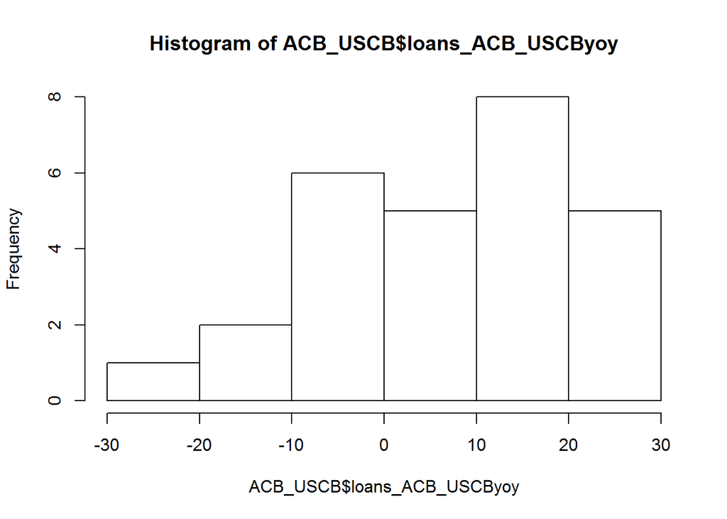

```r
hist(ACB_USCB$loans_ACB_USCByoy)
```

#### Correlation matrix By variables

```r
library(psych)
#pairs.panels(ACB_USCB)
```

```r
source("https://raw.githubusercontent.com/briatte/ggcorr/master/ggcorr.R") # Here I'm using ggcorr as a stand alone function instead of via the GGally package.
#ggcorr(ACB_USCB,
#       label = TRUE,
 #      label_alpha = TRUE,
 #      hjust = 0.75,
  #     size = 3,
   #    low = "steelblue",
    #   mid = "white",
     #  high = "darkred")
```

#### The correlation of the MO selected variables

Test the correlation of the MO Selected variables in the data. This is possibly the rationale for the selected variables for this model

[figure not shown]

```r
ACB_USCB.num=ACB_USCB[c("mo_bfi_nominalyoy","mo_bfi_realyoy","BBBSpread_Bloomberg","futureRateHikeExpect_1y3m","Actuals_CI_Loansyoy")]
pairs.panels(ACB_USCB.num)
```

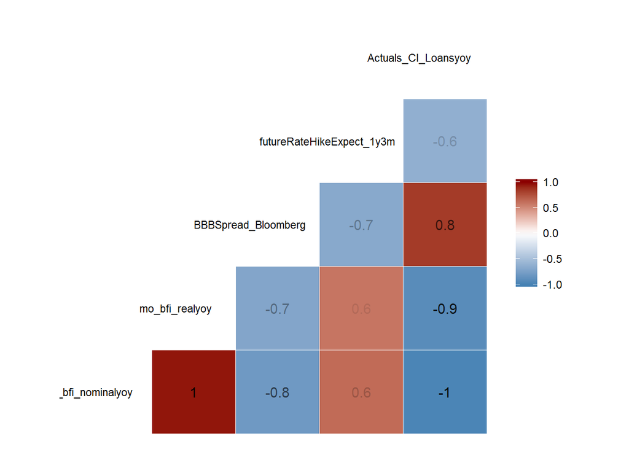

```r
ggcorr(ACB_USCB.num,
       label = TRUE,
       label_alpha = TRUE,
       hjust = 0.75,
       size = 3,
       low = "steelblue",
       mid = "white",
       high = "darkred")
```

The visualization charts above shows that there’s a very strong correlation between mo_bfi_nominalyoy and mo_bfi_realyoy (0.96), BBBSpread_Bloomberg and Actuals_CI_Loansyoy (0.84)

#### library(PerformanceAnalytics)

chart.Correlation(ACB_USCB.num, method = “pearson”,histogram=(TRUE),phc = 16) I decided to use the chart above for a comparison of visualization but ignored it since there is no difference from the previous chart.

### The Initial Model

Model 1. Build the model with all the MO provided Variables for ACB_USCB

```r
ACB_USCB_Model<-lm(loans_ACB_USCByoy ~ mo_bfi_nominalyoy + mo_bfi_realyoy + BBBSpread_Bloomberg + futureRateHikeExpect_1y3m + Actuals_CI_Loansyoy,data = ACB_USCB)
summary(ACB_USCB_Model)
```

```
##
## Call:
## lm(formula = loans_ACB_USCByoy ~ mo_bfi_nominalyoy + mo_bfi_realyoy +
##     BBBSpread_Bloomberg + futureRateHikeExpect_1y3m + Actuals_CI_Loansyoy,
##     data = ACB_USCB)
##
## Residuals:
##     Min      1Q  Median      3Q     Max
## -5.3272 -1.2746  0.1848  1.4274  4.4408
##
## Coefficients:
##                           Estimate Std. Error t value Pr(>|t|)
## (Intercept)                 7.3985     7.9360   0.932 0.362314
## mo_bfi_nominalyoy          -5.1768     1.1893  -4.353 0.000308 ***
## mo_bfi_realyoy              0.9512     0.7083   1.343 0.194311
## BBBSpread_Bloomberg        15.1715     3.9893   3.803 0.001115 **
## futureRateHikeExpect_1y3m  -8.7538    10.2222  -0.856 0.401948
## Actuals_CI_Loansyoy        -1.8937     0.9127  -2.075 0.051132 .
## ---
## Signif. codes:  0 '***' 0.001 '**' 0.01 '*' 0.05 '.' 0.1 ' ' 1
##
## Residual standard error: 2.517 on 20 degrees of freedom
##   (1 observation deleted due to missingness)
## Multiple R-squared:  0.9694, Adjusted R-squared:  0.9618
## F-statistic: 126.8 on 5 and 20 DF,  p-value: 1.947e-14
```

#### Analysis of Variance for Model 1

```r
anova(ACB_USCB_Model)
```

```
## Analysis of Variance Table
##
## Response: loans_ACB_USCByoy
##                           Df Sum Sq Mean Sq  F value    Pr(>F)
## mo_bfi_nominalyoy          1 3831.0  3831.0 604.4897 < 2.2e-16 ***
## mo_bfi_realyoy             1   43.1    43.1   6.8015 0.0168339 *
## BBBSpread_Bloomberg        1   95.3    95.3  15.0383 0.0009358 ***
## futureRateHikeExpect_1y3m  1   20.9    20.9   3.3054 0.0840642 .
## Actuals_CI_Loansyoy        1   27.3    27.3   4.3045 0.0511316 .
## Residuals                 20  126.8     6.3
## ---
## Signif. codes:  0 '***' 0.001 '**' 0.01 '*' 0.05 '.' 0.1 ' ' 1
```

#### Ploting the residuals

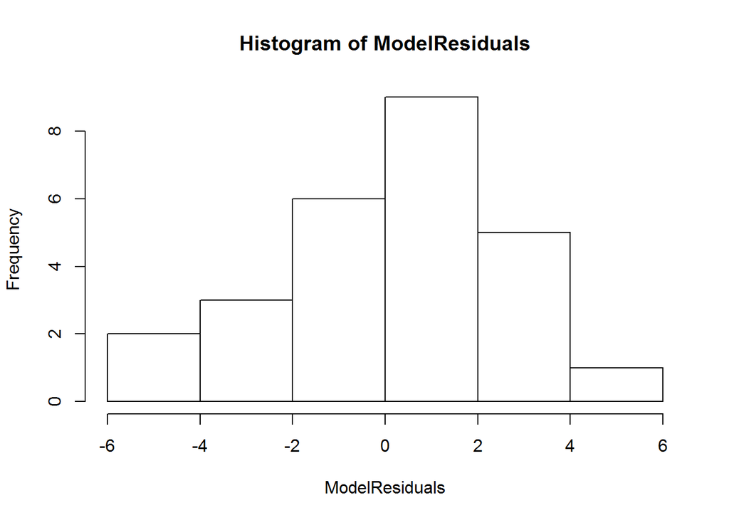

```r
ModelResiduals = residuals(ACB_USCB_Model)
hist(ModelResiduals)
```

#### This chart shows that the Model’s Residuals are Normally Distributed.

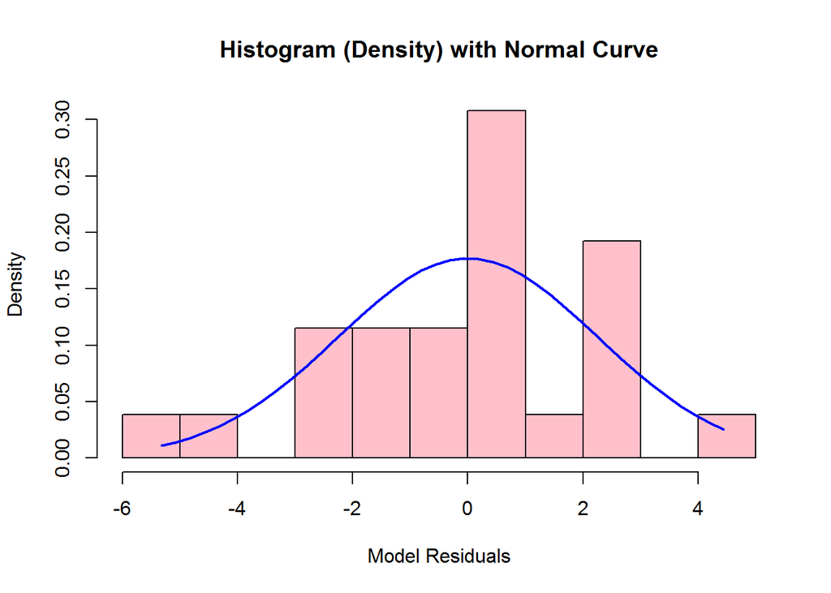

```r
Residual_Distribution <- hist(ModelResiduals, breaks=12, col="Pink", xlab="Model Residuals", main="Histogram (Density) with Normal Curve", freq=FALSE)
xfit <- seq(min(ModelResiduals), max(ModelResiduals), length=40)
yfit_density <- dnorm(xfit, mean=mean(ModelResiduals), sd=sd(ModelResiduals))
lines(xfit, yfit_density, col="blue", lwd=2)
```

The Diagnostic plots provide checks for heteroscedasticity, normality, and influential observerations. Plotting the model shows that the residuals have constant variance when plotted against fitted values(Residuals Vs Fitted graph); and the residuals and fitted values are uncorrelated. From the Normal Q-Q graph, the residuals from the regression model are approximately normally distributed

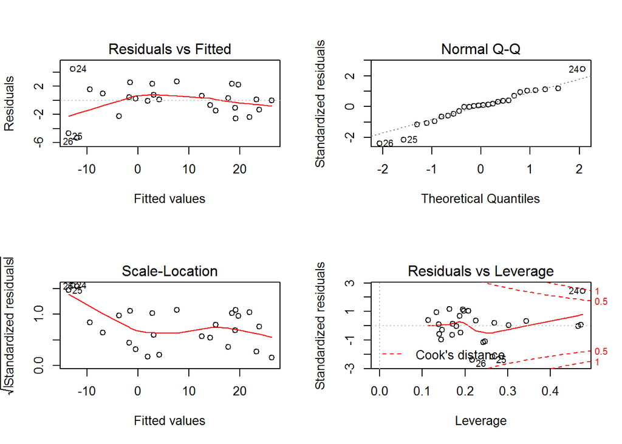

```r
par(mfrow=c(2,2))
plot(ACB_USCB_Model)
```

#### Variable Selection

To Determine the best explanatory variables for the model using Step-wise regression in both direction (Step Forward and Step Backward).

```r
stepMod <- step(ACB_USCB_Model, scope = list(ACB_USCB_Model), direction = "both", trace = 0, steps = 1000)  # perform step-wise algorithm
shortlistedVars <- names(unlist(stepMod[[1]])) # get the shortlisted variable.
shortlistedVars <- shortlistedVars[!shortlistedVars %in% "(Intercept)"]  # remove intercept
print(shortlistedVars) # The following variables were selected from the step-wise method to be significant "mo_bfi_nominalyoy"   "BBBSpread_Bloomberg" "Actuals_CI_Loansyoy"
```

```
## [1] "mo_bfi_nominalyoy"   "BBBSpread_Bloomberg" "Actuals_CI_Loansyoy"
```

#### Using secondary method to identify variable importance

```r
library(caret)
varImp(ACB_USCB_Model)
```

```
##                             Overall
## mo_bfi_nominalyoy         4.3529128
## mo_bfi_realyoy            1.3430127
## BBBSpread_Bloomberg       3.8030695
## futureRateHikeExpect_1y3m 0.8563506
## Actuals_CI_Loansyoy       2.0747321
```

```r
summary(influence.measures(ACB_USCB_Model))
```

```
## Potentially influential observations of
##   lm(formula = loans_ACB_USCByoy ~ mo_bfi_nominalyoy + mo_bfi_realyoy +      BBBSpread_Bloomberg + futureRateHikeExpect_1y3m + Actuals_CI_Loansyoy,      data = ACB_USCB) :
##
##    dfb.1_  dfb.m_bf_n dfb.m_bf_r dfb.BBBS dfb.fRHE dfb.A_CI dffit
## 1  -0.03    0.01       0.03       0.02    -0.02     0.02     0.07
## 2   0.01    0.00       0.00      -0.02     0.00     0.00    -0.02
## 12  0.15   -0.15       0.18      -0.11     0.04    -0.04     0.23
## 15  0.00   -0.01      -0.01       0.02     0.02    -0.02     0.03
## 24 -1.29_*  2.34_*    -1.62_*    -0.26    -1.13_*   1.69_*   2.69_*
##    cov.r   cook.d hat
## 1   2.57_*  0.00   0.47
## 2   2.54_*  0.00   0.46
## 12  2.01_*  0.01   0.34
## 15  1.95_*  0.00   0.30
## 24  0.31    0.90   0.48
```

#### Model performance

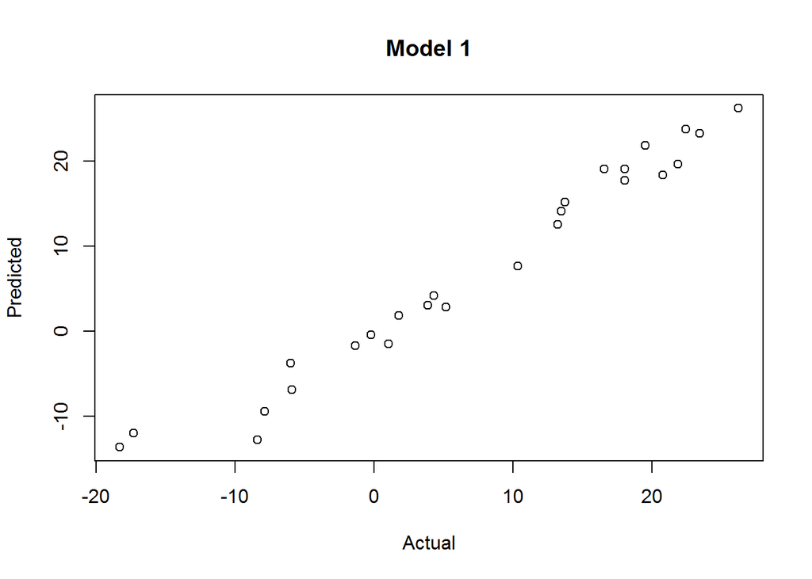

```
## $Models
##   Call
## 1 "lm(formula = loans_ACB_USCByoy ~ mo_bfi_nominalyoy + mo_bfi_realyoy + "
##
## $Fit.criteria
##   Min.max.accuracy  MAE   MAPE  MSE RMSE NRMSE.mean NRMSE.median
## 1            0.979 1.67 0.0396 4.88 2.21      0.305        0.285
##   NRMSE.mean.accuracy NRMSE.median.accuracy Efron.r.squared
## 1               0.695                 0.715           0.969
```

```r
accuracy(list(ACB_USCB_Model),plotit=TRUE, digits=3)
```

### Model 2. With the Selected variables

```r
ACB_USCB_Model_2<-lm(loans_ACB_USCByoy ~ mo_bfi_nominalyoy + BBBSpread_Bloomberg + Actuals_CI_Loansyoy,data = ACB_USCB)
summary(ACB_USCB_Model_2) # There is no significant difference in the R-Squared value from the first model.
```

```
##
## Call:
## lm(formula = loans_ACB_USCByoy ~ mo_bfi_nominalyoy + BBBSpread_Bloomberg +
##     Actuals_CI_Loansyoy, data = ACB_USCB)
##
## Residuals:
##     Min      1Q  Median      3Q     Max
## -5.4895 -1.1965  0.1678  1.6757  3.6537
##
## Coefficients:
##                     Estimate Std. Error t value Pr(>|t|)
## (Intercept)           1.4809     6.9382   0.213   0.8329
## mo_bfi_nominalyoy    -4.5512     0.8299  -5.484 1.64e-05 ***
## BBBSpread_Bloomberg  18.0087     3.4954   5.152 3.65e-05 ***
## Actuals_CI_Loansyoy  -2.0134     0.8337  -2.415   0.0245 *
## ---
## Signif. codes:  0 '***' 0.001 '**' 0.01 '*' 0.05 '.' 0.1 ' ' 1
##
## Residual standard error: 2.539 on 22 degrees of freedom
##   (1 observation deleted due to missingness)
## Multiple R-squared:  0.9658, Adjusted R-squared:  0.9611
## F-statistic: 206.9 on 3 and 22 DF,  p-value: 2.877e-16
```

#### Analysis of Variance for Model 2

```r
anova(ACB_USCB_Model_2)
```

```
## Analysis of Variance Table
##
## Response: loans_ACB_USCByoy
##                     Df Sum Sq Mean Sq  F value    Pr(>F)
## mo_bfi_nominalyoy    1 3831.0  3831.0 594.1197 < 2.2e-16 ***
## BBBSpread_Bloomberg  1  133.9   133.9  20.7687 0.0001547 ***
## Actuals_CI_Loansyoy  1   37.6    37.6   5.8327 0.0244875 *
## Residuals           22  141.9     6.4
## ---
## Signif. codes:  0 '***' 0.001 '**' 0.01 '*' 0.05 '.' 0.1 ' ' 1
```

#### Plotting the model

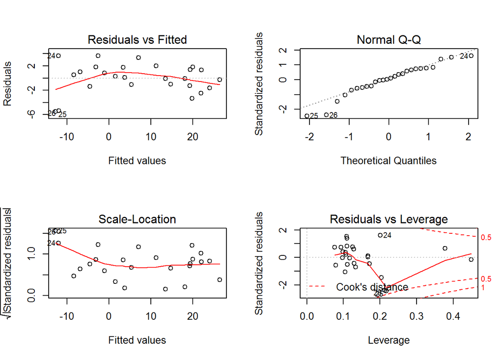

```r
par(mfrow=c(2,2))
plot(ACB_USCB_Model_2)
```

#### Model Performance

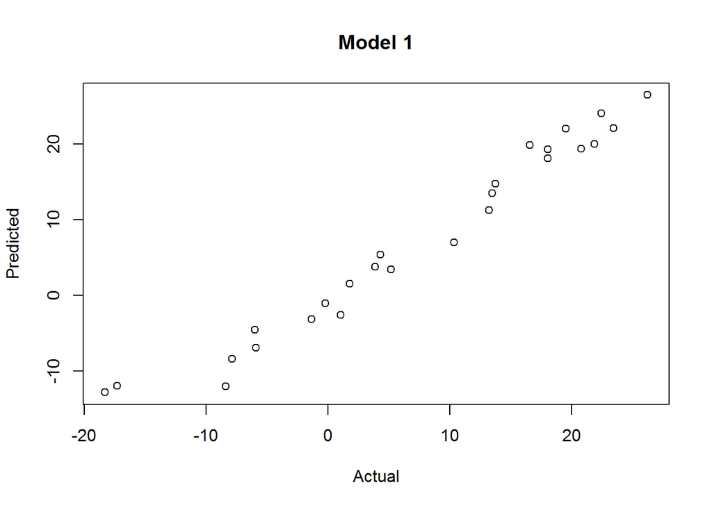

```
## $Models
##   Call
## 1 "lm(formula = loans_ACB_USCByoy ~ mo_bfi_nominalyoy + BBBSpread_Bloomberg + "
##
## $Fit.criteria
##   Min.max.accuracy  MAE    MAPE  MSE RMSE NRMSE.mean NRMSE.median
## 1             1.07 1.81 -0.0567 5.46 2.34      0.322        0.301
##   NRMSE.mean.accuracy NRMSE.median.accuracy Efron.r.squared
## 1               0.678                 0.699           0.966
```

```r
accuracy(list(ACB_USCB_Model_2),plotit=TRUE, digits=3)
```

#### Ceating a train and test data sets

The following code splits 70% of the data selected randomly into training set and the remaining 30% sample into test data set.

```r
ACB = sort(sample(nrow(ACB_USCB), nrow(ACB_USCB)*.7))
Train_ACB<-ACB_USCB[ACB,]
Test_ACB<-ACB_USCB[-ACB,]
```

### Build Model 3 on the train data set

```r
ACB_USCB_Model_3<-lm(loans_ACB_USCByoy ~ mo_bfi_nominalyoy + BBBSpread_Bloomberg + Actuals_CI_Loansyoy,data = Train_ACB)
summary(ACB_USCB_Model_3)
```

```
##
## Call:
## lm(formula = loans_ACB_USCByoy ~ mo_bfi_nominalyoy + BBBSpread_Bloomberg +
##     Actuals_CI_Loansyoy, data = Train_ACB)
##
## Residuals:
##     Min      1Q  Median      3Q     Max
## -2.4049 -1.0232  0.0447  0.8734  1.7808
##
## Coefficients:
##                     Estimate Std. Error t value Pr(>|t|)
## (Intercept)          -9.7838     5.1768  -1.890   0.0813 .
## mo_bfi_nominalyoy    -2.2818     0.7584  -3.009   0.0101 *
## BBBSpread_Bloomberg  14.4838     2.0490   7.069 8.43e-06 ***
## Actuals_CI_Loansyoy   0.0887     0.7121   0.125   0.9028
## ---
## Signif. codes:  0 '***' 0.001 '**' 0.01 '*' 0.05 '.' 0.1 ' ' 1
##
## Residual standard error: 1.285 on 13 degrees of freedom
##   (1 observation deleted due to missingness)
## Multiple R-squared:  0.9899, Adjusted R-squared:  0.9875
## F-statistic:   423 on 3 and 13 DF,  p-value: 3.314e-13
```

##### Analysis of Variance for Model 3

```r
anova(ACB_USCB_Model_3)
```

```
## Analysis of Variance Table
##
## Response: loans_ACB_USCByoy
##                     Df  Sum Sq Mean Sq   F value    Pr(>F)
## mo_bfi_nominalyoy    1 1980.36 1980.36 1200.1169 3.419e-14 ***
## BBBSpread_Bloomberg  1  113.55  113.55   68.8152 1.500e-06 ***
## Actuals_CI_Loansyoy  1    0.03    0.03    0.0155    0.9028
## Residuals           13   21.45    1.65
## ---
## Signif. codes:  0 '***' 0.001 '**' 0.01 '*' 0.05 '.' 0.1 ' ' 1
```

#### Predicting ACB_USCB Loan on the test data set

```r
Pred_Loan <- predict(ACB_USCB_Model_3, Test_ACB)
```

#### Model Performance

Obtain the Accuracy for 3 Models

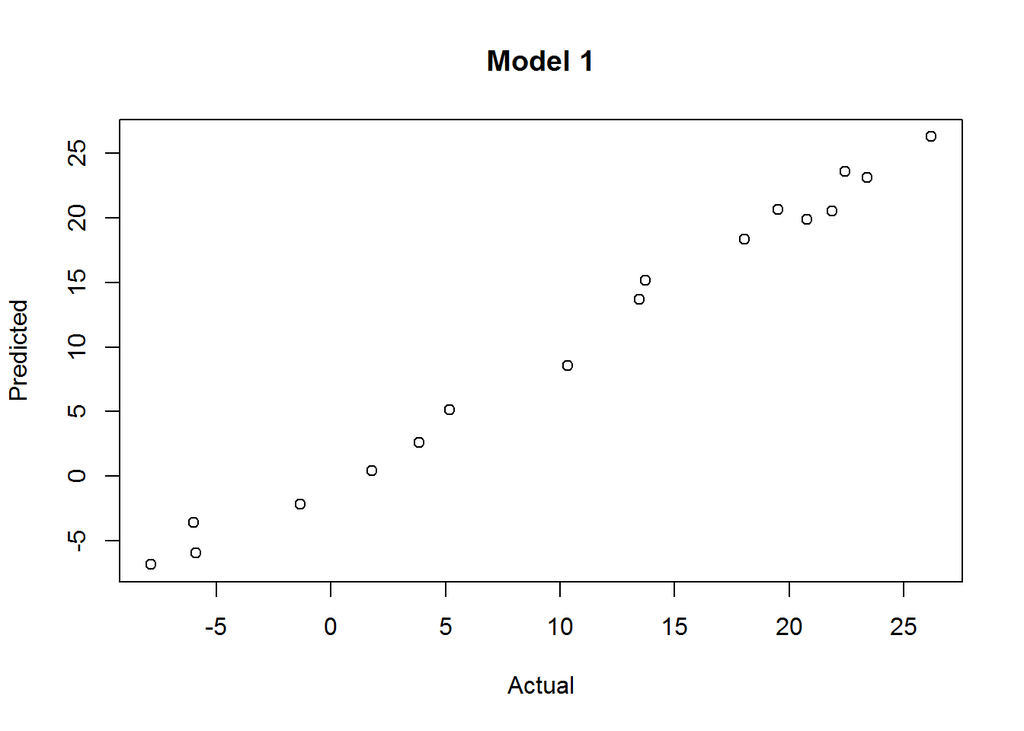

```
## $Models
##   Call
## 1 "lm(formula = loans_ACB_USCByoy ~ mo_bfi_nominalyoy + BBBSpread_Bloomberg + "
##
## $Fit.criteria
##   Min.max.accuracy   MAE   MAPE  MSE RMSE NRMSE.mean NRMSE.median
## 1             0.99 0.913 0.0278 1.26 1.12      0.106       0.0835
##   NRMSE.mean.accuracy NRMSE.median.accuracy Efron.r.squared
## 1               0.894                 0.916            0.99
```

```r
accuracy(list(ACB_USCB_Model_3),plotit=TRUE, digits=3)
```

#### Creating models using each of the Explanatory Variable on the Train Dataset

### Model 4

#### Analysis of Variance for Model 4 without Caret

```r
ACB_USCB_Model_4<-lm(loans_ACB_USCByoy ~ mo_bfi_nominalyoy,data = Train_ACB)
summary(ACB_USCB_Model_4)
```

```
##
## Call:
## lm(formula = loans_ACB_USCByoy ~ mo_bfi_nominalyoy, data = Train_ACB)
##
## Residuals:
##      Min       1Q   Median       3Q      Max
## -10.0065  -1.8644  -0.2171   2.8349   6.1358
##
## Coefficients:
##                   Estimate Std. Error t value Pr(>|t|)
## (Intercept)        16.5883     1.1180   14.84 8.99e-11 ***
## mo_bfi_nominalyoy  -3.6906     0.2821  -13.08 5.82e-10 ***
## ---
## Signif. codes:  0 '***' 0.001 '**' 0.01 '*' 0.05 '.' 0.1 ' ' 1
##
## Residual standard error: 4.021 on 16 degrees of freedom
## Multiple R-squared:  0.9145, Adjusted R-squared:  0.9092
## F-statistic: 171.2 on 1 and 16 DF,  p-value: 5.822e-10
```

```r
anova(ACB_USCB_Model_4)
```

```
## Analysis of Variance Table
##
## Response: loans_ACB_USCByoy
##                   Df  Sum Sq Mean Sq F value    Pr(>F)
## mo_bfi_nominalyoy  1 2768.36 2768.36  171.19 5.822e-10 ***
## Residuals         16  258.75   16.17
## ---
## Signif. codes:  0 '***' 0.001 '**' 0.01 '*' 0.05 '.' 0.1 ' ' 1
```

#### Predicting

```r
Pred_Loan <- predict(ACB_USCB_Model_4, Test_ACB)
```

#### Model performance

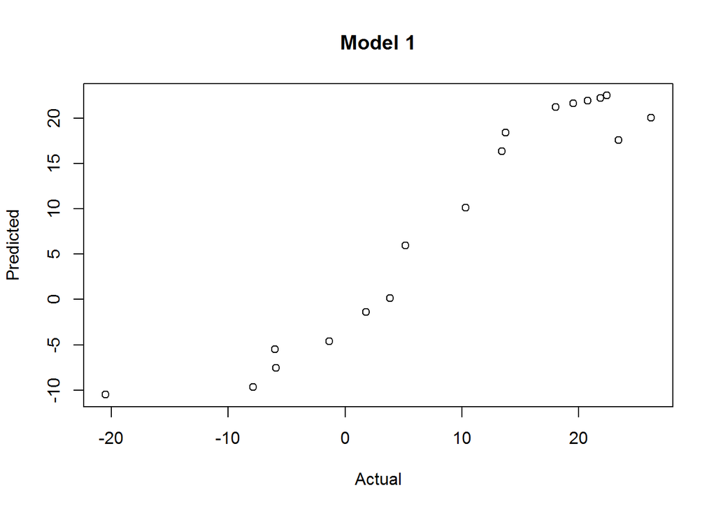

```
## $Models
##   Call
## 1 "lm(formula = loans_ACB_USCByoy ~ mo_bfi_nominalyoy, data = Train_ACB)"
##
## $Fit.criteria
##   Min.max.accuracy  MAE   MAPE  MSE RMSE NRMSE.mean NRMSE.median
## 1            0.995 2.86 0.0413 14.4 3.79      0.429        0.319
##   NRMSE.mean.accuracy NRMSE.median.accuracy Efron.r.squared
## 1               0.571                 0.681           0.915
```

```r
accuracy(list(ACB_USCB_Model_4),plotit=TRUE, digits=3)
```

### Model 5

#### Analysis of Variance for Model 5 without Caret

```r
ACB_USCB_Model_5<-lm(loans_ACB_USCByoy ~ BBBSpread_Bloomberg,data = Train_ACB)
summary(ACB_USCB_Model_5)
```

```
##
## Call:
## lm(formula = loans_ACB_USCByoy ~ BBBSpread_Bloomberg, data = Train_ACB)
##
## Residuals:
##     Min      1Q  Median      3Q     Max
## -6.8670 -3.7629 -0.3033  5.2608  6.2557
##
## Coefficients:
##                     Estimate Std. Error t value Pr(>|t|)
## (Intercept)          -48.168      7.544  -6.385 1.23e-05 ***
## BBBSpread_Bloomberg   35.630      4.512   7.897 1.01e-06 ***
## ---
## Signif. codes:  0 '***' 0.001 '**' 0.01 '*' 0.05 '.' 0.1 ' ' 1
##
## Residual standard error: 5.229 on 15 degrees of freedom
##   (1 observation deleted due to missingness)
## Multiple R-squared:  0.8061, Adjusted R-squared:  0.7932
## F-statistic: 62.36 on 1 and 15 DF,  p-value: 1.01e-06
```

```r
anova(ACB_USCB_Model_5)
```

```
## Analysis of Variance Table
##
## Response: loans_ACB_USCByoy
##                     Df  Sum Sq Mean Sq F value   Pr(>F)
## BBBSpread_Bloomberg  1 1705.24 1705.24  62.364 1.01e-06 ***
## Residuals           15  410.15   27.34
## ---
## Signif. codes:  0 '***' 0.001 '**' 0.01 '*' 0.05 '.' 0.1 ' ' 1
```

#### Predicting

```r
Pred_Loan <- predict(ACB_USCB_Model_5, Test_ACB)
```

#### Model Performance

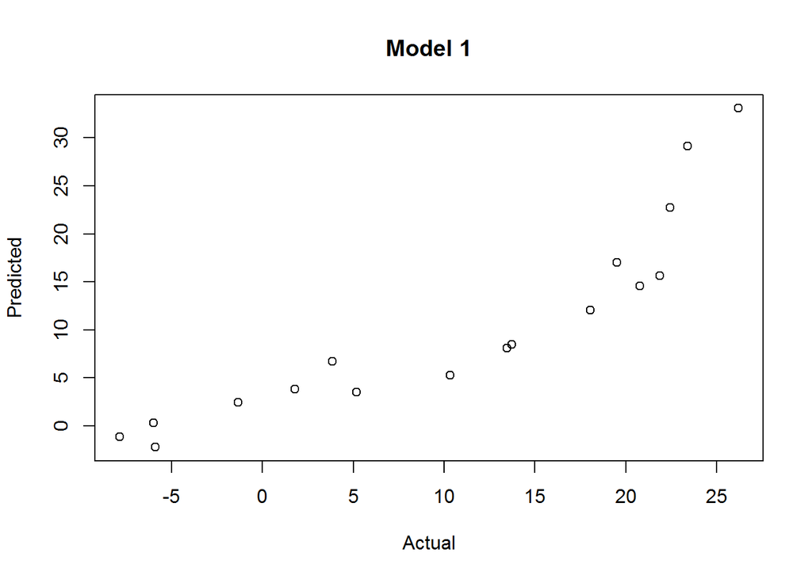

```
## $Models
##   Call
## 1 "lm(formula = loans_ACB_USCByoy ~ BBBSpread_Bloomberg, data = Train_ACB)"
##
## $Fit.criteria
##   Min.max.accuracy  MAE    MAPE  MSE RMSE NRMSE.mean NRMSE.median
## 1           -0.159 4.51 -0.0171 24.1 4.91      0.465        0.365
##   NRMSE.mean.accuracy NRMSE.median.accuracy Efron.r.squared
## 1               0.535                 0.635           0.806
```

```r
accuracy(list(ACB_USCB_Model_5),plotit=TRUE, digits=3)
```

### Model 6

```r
ACB_USCB_Model_6<-lm(loans_ACB_USCByoy ~ Actuals_CI_Loansyoy,data = Train_ACB)
summary(ACB_USCB_Model_6)
```

```
##
## Call:
## lm(formula = loans_ACB_USCByoy ~ Actuals_CI_Loansyoy, data = Train_ACB)
##
## Residuals:
##      Min       1Q   Median       3Q      Max
## -17.8214  -0.8554   0.0416   2.5138   6.4591
##
## Coefficients:
##                     Estimate Std. Error t value Pr(>|t|)
## (Intercept)         -10.9705     2.4474  -4.483 0.000377 ***
## Actuals_CI_Loansyoy   3.2344     0.3423   9.449 6.01e-08 ***
## ---
## Signif. codes:  0 '***' 0.001 '**' 0.01 '*' 0.05 '.' 0.1 ' ' 1
##
## Residual standard error: 5.362 on 16 degrees of freedom
## Multiple R-squared:  0.848,  Adjusted R-squared:  0.8385
## F-statistic: 89.28 on 1 and 16 DF,  p-value: 6.009e-08
```

```r
anova(ACB_USCB_Model_6)
```

```
## Analysis of Variance Table
##
## Response: loans_ACB_USCByoy
##                     Df  Sum Sq Mean Sq F value    Pr(>F)
## Actuals_CI_Loansyoy  1 2567.07 2567.07  89.281 6.009e-08 ***
## Residuals           16  460.04   28.75
## ---
## Signif. codes:  0 '***' 0.001 '**' 0.01 '*' 0.05 '.' 0.1 ' ' 1
```

#### Predicting

```r
Pred_Loan <- predict(ACB_USCB_Model_6, Test_ACB)
```

#### Model Performance

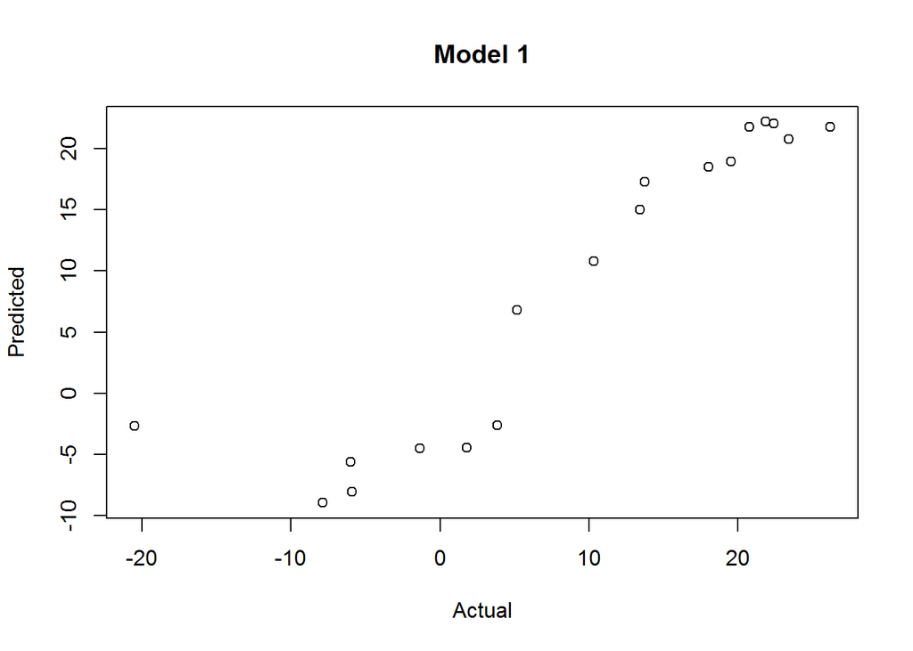

```
## $Models
##   Call
## 1 "lm(formula = loans_ACB_USCByoy ~ Actuals_CI_Loansyoy, data = Train_ACB)"
##
## $Fit.criteria
##   Min.max.accuracy  MAE MAPE  MSE RMSE NRMSE.mean NRMSE.median
## 1             1.19 3.01 0.14 25.6 5.06      0.572        0.425
##   NRMSE.mean.accuracy NRMSE.median.accuracy Efron.r.squared
## 1               0.428                 0.575           0.848
```

```r
accuracy(list(ACB_USCB_Model_6),plotit=TRUE, digits=3)
```

#### Plot All Models to determine the Best Fit

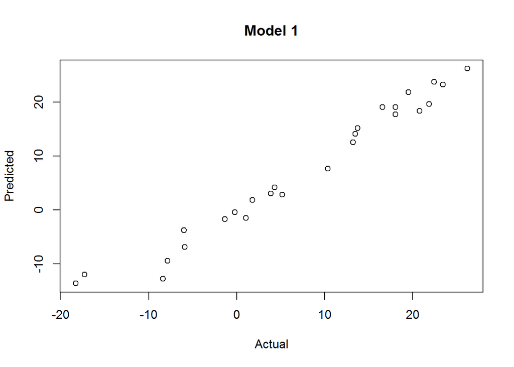

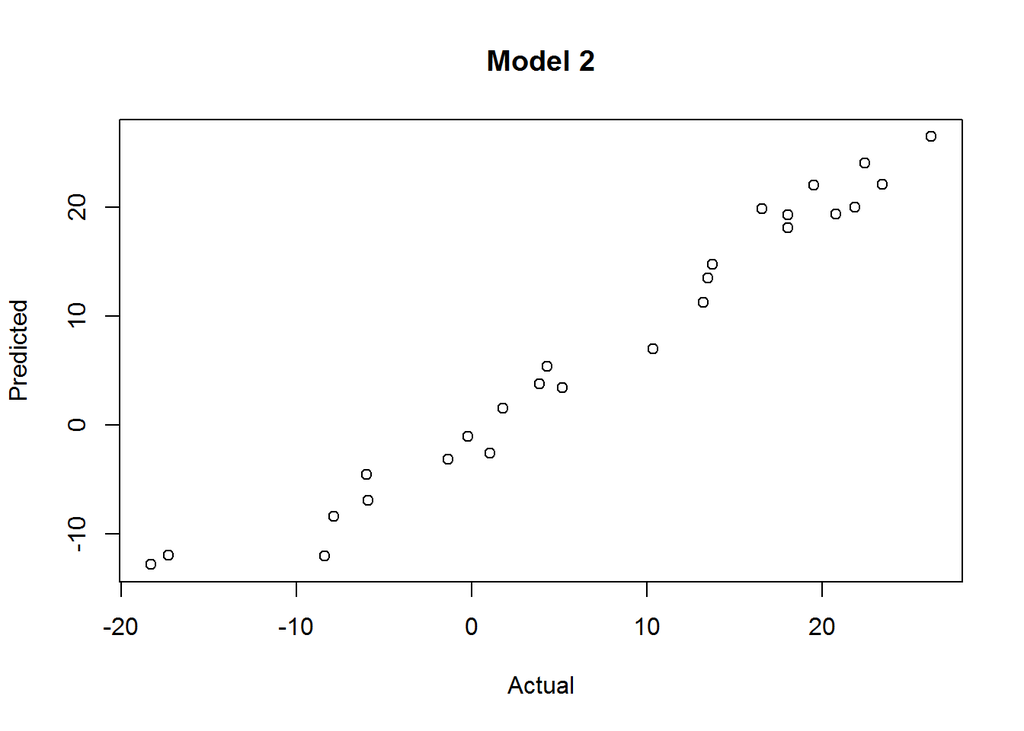

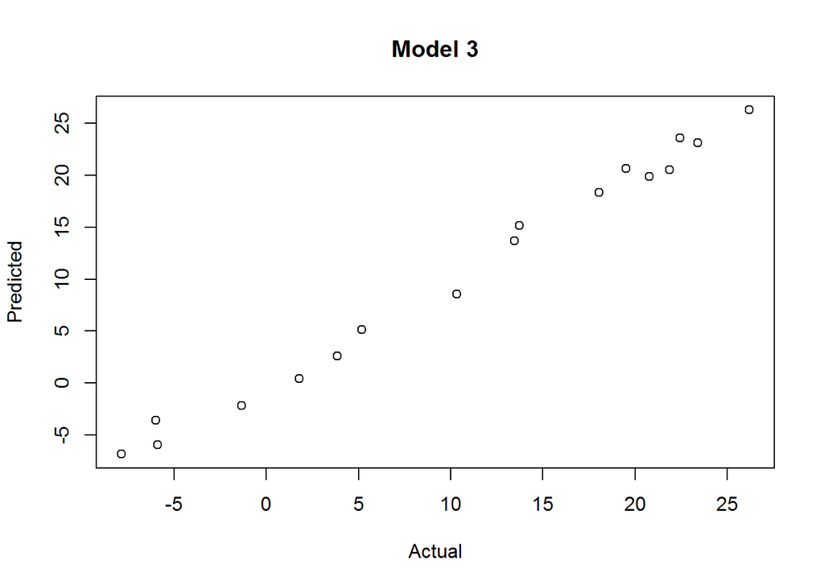

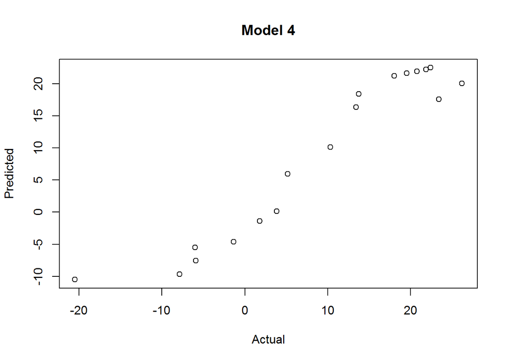

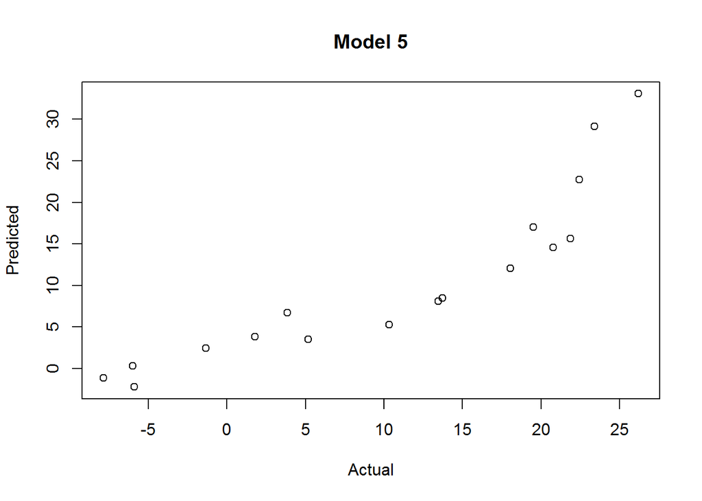

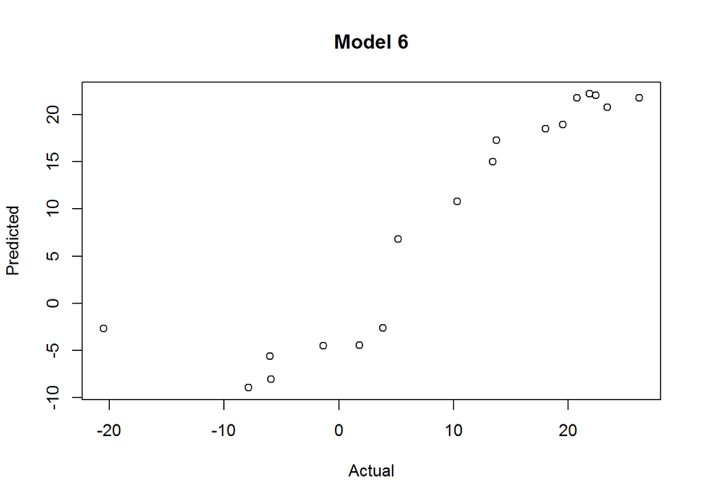

```
## $Models
##   Call
## 1 "lm(formula = loans_ACB_USCByoy ~ mo_bfi_nominalyoy + mo_bfi_realyoy + "
## 2 "lm(formula = loans_ACB_USCByoy ~ mo_bfi_nominalyoy + BBBSpread_Bloomberg + "
## 3 "lm(formula = loans_ACB_USCByoy ~ mo_bfi_nominalyoy + BBBSpread_Bloomberg + "
## 4 "lm(formula = loans_ACB_USCByoy ~ mo_bfi_nominalyoy, data = Train_ACB)"
## 5 "lm(formula = loans_ACB_USCByoy ~ BBBSpread_Bloomberg, data = Train_ACB)"
## 6 "lm(formula = loans_ACB_USCByoy ~ Actuals_CI_Loansyoy, data = Train_ACB)"
##
## $Fit.criteria
##   Min.max.accuracy   MAE    MAPE   MSE RMSE NRMSE.mean NRMSE.median
## 1            0.979 1.670  0.0396  4.88 2.21      0.305       0.2850
## 2            1.070 1.810 -0.0567  5.46 2.34      0.322       0.3010
## 3            0.990 0.913  0.0278  1.26 1.12      0.106       0.0835
## 4            0.995 2.860  0.0413 14.40 3.79      0.429       0.3190
## 5           -0.159 4.510 -0.0171 24.10 4.91      0.465       0.3650
## 6            1.190 3.010  0.1400 25.60 5.06      0.572       0.4250
##   NRMSE.mean.accuracy NRMSE.median.accuracy Efron.r.squared
## 1               0.695                 0.715           0.969
## 2               0.678                 0.699           0.966
## 3               0.894                 0.916           0.990
## 4               0.571                 0.681           0.915
## 5               0.535                 0.635           0.806
## 6               0.428                 0.575           0.848
```

```r
accuracy(list(ACB_USCB_Model,ACB_USCB_Model_2,ACB_USCB_Model_3, ACB_USCB_Model_4, ACB_USCB_Model_5,ACB_USCB_Model_6),plotit=TRUE, digits=3)
```

**End——————————————————————————————-End**

### Cross Validation of Models using Caret Package

This process uses an accelerated cross-validation which produces predicted R-Squared without the need for train and test dataset TrainControl for cross validation using k=10

```r
Control <- trainControl(method = "cv", number = 10)
```

### Model 3a

```r
ACB_USCB_Model_3a<-train(loans_ACB_USCByoy ~ mo_bfi_nominalyoy + BBBSpread_Bloomberg + Actuals_CI_Loansyoy,data = ACB_USCB,trControl = Control, method ="lm",na.action = na.pass)
summary(ACB_USCB_Model_3a)
```

```
##
## Call:
## lm(formula = .outcome ~ ., data = dat)
##
## Residuals:
##     Min      1Q  Median      3Q     Max
## -5.4895 -1.1965  0.1678  1.6757  3.6537
##
## Coefficients:
##                     Estimate Std. Error t value Pr(>|t|)
## (Intercept)           1.4809     6.9382   0.213   0.8329
## mo_bfi_nominalyoy    -4.5512     0.8299  -5.484 1.64e-05 ***
## BBBSpread_Bloomberg  18.0087     3.4954   5.152 3.65e-05 ***
## Actuals_CI_Loansyoy  -2.0134     0.8337  -2.415   0.0245 *
## ---
## Signif. codes:  0 '***' 0.001 '**' 0.01 '*' 0.05 '.' 0.1 ' ' 1
##
## Residual standard error: 2.539 on 22 degrees of freedom
##   (1 observation deleted due to missingness)
## Multiple R-squared:  0.9658, Adjusted R-squared:  0.9611
## F-statistic: 206.9 on 3 and 22 DF,  p-value: 2.877e-16
```

```r
ACB_USCB_Model_3a
```

```
## Linear Regression
##
## 27 samples
##  3 predictor
##
## No pre-processing
## Resampling: Cross-Validated (10 fold)
## Summary of sample sizes: 24, 25, 24, 24, 24, 24, ...
## Resampling results:
##
##   RMSE      Rsquared  MAE
##   2.510346  0.995876  2.215802
##
## Tuning parameter 'intercept' was held constant at a value of TRUE
```

```r
ACB_USCB_Model_3a$resample
```

```
##         RMSE  Rsquared       MAE Resample
## 1  4.2326838 0.9998572 3.3158179   Fold01
## 2  2.3112512 1.0000000 2.2770954   Fold02
## 3  1.1919550 1.0000000 1.0715317   Fold03
## 4  4.1349507 0.9997329 3.2967722   Fold04
## 5  0.9345598 0.9999429 0.7920156   Fold05
## 6  1.3814609 0.9748669 1.1429826   Fold06
## 7  3.3901107 1.0000000 3.2704061   Fold07
## 8  0.9329964 0.9979251 0.8025746   Fold08
## 9  3.6150221 1.0000000 3.4055792   Fold09
## 10 2.9784682 0.9864351 2.7832481   Fold10
```

### Model 4a

```r
ACB_USCB_Model_4a<-train(loans_ACB_USCByoy ~ mo_bfi_nominalyoy,data = ACB_USCB,trControl = Control, method ="lm",na.action = na.pass)
summary(ACB_USCB_Model_4a)
```

```
##
## Call:
## lm(formula = .outcome ~ ., data = dat)
##
## Residuals:
##    Min     1Q Median     3Q    Max
## -9.789 -2.328 -0.013  3.208  6.468
##
## Coefficients:
##                   Estimate Std. Error t value Pr(>|t|)
## (Intercept)        16.2686     1.0010   16.25 8.47e-15 ***
## mo_bfi_nominalyoy  -3.6767     0.2255  -16.30 7.85e-15 ***
## ---
## Signif. codes:  0 '***' 0.001 '**' 0.01 '*' 0.05 '.' 0.1 ' ' 1
##
## Residual standard error: 4.099 on 25 degrees of freedom
## Multiple R-squared:  0.914,  Adjusted R-squared:  0.9106
## F-statistic: 265.9 on 1 and 25 DF,  p-value: 7.852e-15
```

```r
ACB_USCB_Model_4a
```

```
## Linear Regression
##
## 27 samples
##  1 predictor
##
## No pre-processing
## Resampling: Cross-Validated (10 fold)
## Summary of sample sizes: 24, 24, 24, 24, 24, 25, ...
## Resampling results:
##
##   RMSE     Rsquared   MAE
##   3.92916  0.9621285  3.439114
##
## Tuning parameter 'intercept' was held constant at a value of TRUE
```

```r
ACB_USCB_Model_4a$resample
```

```
##        RMSE  Rsquared       MAE Resample
## 1  5.174905 0.9112594 4.7599473   Fold01
## 2  3.634229 0.9950272 3.5187849   Fold02
## 3  1.279947 0.9973613 0.9982664   Fold03
## 4  2.185717 0.8747428 1.3897455   Fold04
## 5  4.848431 0.9438462 4.1471274   Fold05
## 6  4.703962 1.0000000 3.7224852   Fold06
## 7  6.642043 0.9018179 5.3091190   Fold07
## 8  2.165194 1.0000000 1.9815847   Fold08
## 9  2.920565 0.9972307 2.8830170   Fold09
## 10 5.736608 1.0000000 5.6810582   Fold10
```

### Model 5a

```r
ACB_USCB_Model_5a<-train(loans_ACB_USCByoy ~ BBBSpread_Bloomberg,data = ACB_USCB,trControl = Control, method ="lm",na.action = na.pass)
summary(ACB_USCB_Model_5a)
```

```
##
## Call:
## lm(formula = .outcome ~ ., data = dat)
##
## Residuals:
##      Min       1Q   Median       3Q      Max
## -11.7865  -3.4616  -0.6017   5.8275   9.1122
##
## Coefficients:
##                     Estimate Std. Error t value Pr(>|t|)
## (Intercept)          -58.803      7.393  -7.954 3.50e-08 ***
## BBBSpread_Bloomberg   41.947      4.630   9.060 3.26e-09 ***
## ---
## Signif. codes:  0 '***' 0.001 '**' 0.01 '*' 0.05 '.' 0.1 ' ' 1
##
## Residual standard error: 6.251 on 24 degrees of freedom
##   (1 observation deleted due to missingness)
## Multiple R-squared:  0.7738, Adjusted R-squared:  0.7643
## F-statistic: 82.08 on 1 and 24 DF,  p-value: 3.26e-09
```

```r
ACB_USCB_Model_5a
```

```
## Linear Regression
##
## 27 samples
##  1 predictor
##
## No pre-processing
## Resampling: Cross-Validated (10 fold)
## Summary of sample sizes: 24, 24, 25, 24, 25, 24, ...
## Resampling results:
##
##   RMSE      Rsquared  MAE
##   5.977217  0.972112  5.360975
##
## Tuning parameter 'intercept' was held constant at a value of TRUE
```

```r
ACB_USCB_Model_5a$resample
```

```
##         RMSE  Rsquared      MAE Resample
## 1  10.629926 0.9260531 9.059636   Fold01
## 2   3.548823 0.9849937 2.526134   Fold02
## 3   2.736025 1.0000000 2.593195   Fold03
## 4   7.196599 0.9997544 6.437414   Fold04
## 5   4.706300 1.0000000 4.173275   Fold05
## 6   5.024093 1.0000000 4.835098   Fold06
## 7   4.526655 1.0000000 3.967119   Fold07
## 8   4.545554 0.8510386 4.264161   Fold08
## 9   8.661524 0.9618425 8.570121   Fold09
## 10  8.196671 0.9974373 7.183592   Fold10
```

### Model 6a

```r
ACB_USCB_Model_6a<-train(loans_ACB_USCByoy ~ Actuals_CI_Loansyoy,data = ACB_USCB,trControl = Control, method ="lm",na.action = na.pass)
summary(ACB_USCB_Model_6a)
```

```
##
## Call:
## lm(formula = .outcome ~ ., data = dat)
##
## Residuals:
##      Min       1Q   Median       3Q      Max
## -17.4411  -1.1339   0.2046   3.1432   7.2911
##
## Coefficients:
##                     Estimate Std. Error t value Pr(>|t|)
## (Intercept)         -11.6399     1.8786  -6.196 1.76e-06 ***
## Actuals_CI_Loansyoy   3.3473     0.2896  11.558 1.60e-11 ***
## ---
## Signif. codes:  0 '***' 0.001 '**' 0.01 '*' 0.05 '.' 0.1 ' ' 1
##
## Residual standard error: 5.551 on 25 degrees of freedom
## Multiple R-squared:  0.8424, Adjusted R-squared:  0.836
## F-statistic: 133.6 on 1 and 25 DF,  p-value: 1.6e-11
```

```r
ACB_USCB_Model_6a
```

```
## Linear Regression
##
## 27 samples
##  1 predictor
##
## No pre-processing
## Resampling: Cross-Validated (10 fold)
## Summary of sample sizes: 24, 24, 24, 24, 24, 25, ...
## Resampling results:
##
##   RMSE      Rsquared   MAE
##   4.739118  0.9047837  3.728772
##
## Tuning parameter 'intercept' was held constant at a value of TRUE
```

```r
ACB_USCB_Model_6a$resample
```

```
##         RMSE  Rsquared       MAE Resample
## 1  11.119188 0.3884979 8.3923793   Fold01
## 2   4.024580 0.9617116 3.6164443   Fold02
## 3   4.260230 0.9352056 2.9391105   Fold03
## 4   4.352765 0.9845120 3.3137120   Fold04
## 5   1.720692 0.9999999 1.0996742   Fold05
## 6   0.627842 1.0000000 0.6195729   Fold06
## 7   3.941534 0.7890452 3.2972935   Fold07
## 8   6.087787 0.9888647 3.9424169   Fold08
## 9   7.872786 1.0000000 6.8485680   Fold09
## 10  3.383772 1.0000000 3.2185492   Fold10
```

#### Combined results from the Cross validation

```r
ACB_USCB_Model_3a
```

```
## Linear Regression
##
## 27 samples
##  3 predictor
##
## No pre-processing
## Resampling: Cross-Validated (10 fold)
## Summary of sample sizes: 24, 25, 24, 24, 24, 24, ...
## Resampling results:
##
##   RMSE      Rsquared  MAE
##   2.510346  0.995876  2.215802
##
## Tuning parameter 'intercept' was held constant at a value of TRUE
```

```r
ACB_USCB_Model_4a
```

```
## Linear Regression
##
## 27 samples
##  1 predictor
##
## No pre-processing
## Resampling: Cross-Validated (10 fold)
## Summary of sample sizes: 24, 24, 24, 24, 24, 25, ...
## Resampling results:
##
##   RMSE     Rsquared   MAE
##   3.92916  0.9621285  3.439114
##
## Tuning parameter 'intercept' was held constant at a value of TRUE
```

```r
ACB_USCB_Model_5a
```

```
## Linear Regression
##
## 27 samples
##  1 predictor
##
## No pre-processing
## Resampling: Cross-Validated (10 fold)
## Summary of sample sizes: 24, 24, 25, 24, 25, 24, ...
## Resampling results:
##
##   RMSE      Rsquared  MAE
##   5.977217  0.972112  5.360975
##
## Tuning parameter 'intercept' was held constant at a value of TRUE
```

```r
ACB_USCB_Model_6a
```

```
## Linear Regression
##
## 27 samples
##  1 predictor
##
## No pre-processing
## Resampling: Cross-Validated (10 fold)
## Summary of sample sizes: 24, 24, 24, 24, 24, 25, ...
## Resampling results:
##
##   RMSE      Rsquared   MAE
##   4.739118  0.9047837  3.728772
##
## Tuning parameter 'intercept' was held constant at a value of TRUE
```

#### Plot All Models to determine the Best Fit

Model Prediction with Three Predictor Variables

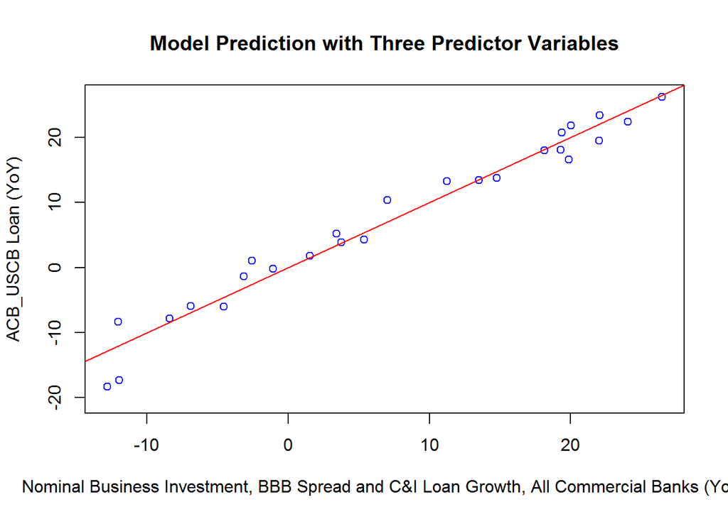

```r
plot(predict(ACB_USCB_Model_3a),ACB_USCB$loans_ACB_USCByoy,
     xlab = "Nominal Business Investment, BBB Spread and C&I Loan Growth, All Commercial Banks (YoY)", ylab = "ACB_USCB Loan (YoY)", main = "Model Prediction with Three Predictor Variables", col ="blue")
abline(a=0, b=1, col= "red")
```

Model Prediction with One Predictor Variable (Nominal Business Investment)

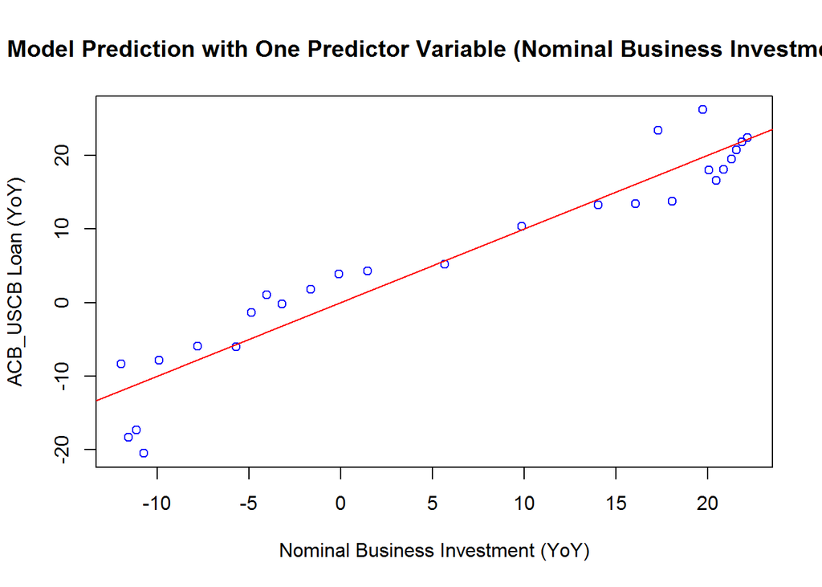

```r
plot(predict(ACB_USCB_Model_4a),ACB_USCB$loans_ACB_USCByoy,
     xlab = "Nominal Business Investment (YoY)", ylab = "ACB_USCB Loan (YoY)", main = "Model Prediction with One Predictor Variable (Nominal Business Investment)", col ="blue")
abline(a=0, b=1, col= "red")
```

Model Prediction with One Predictor Variable (BBB Spread)

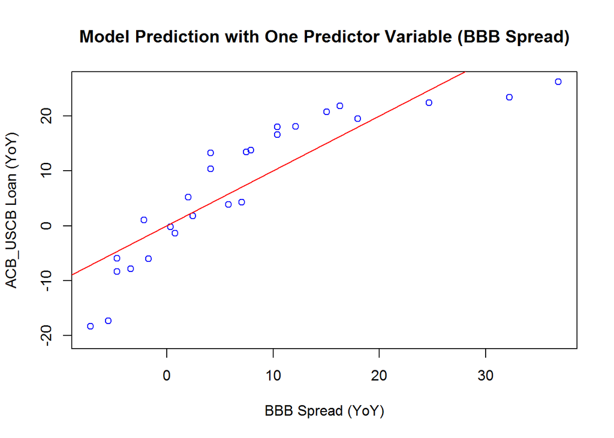

```r
plot(predict(ACB_USCB_Model_5a),ACB_USCB$loans_ACB_USCByoy,
     xlab = "BBB Spread (YoY)", ylab = "ACB_USCB Loan (YoY)", main = "Model Prediction with One Predictor Variable (BBB Spread)", col ="blue")
abline(a=0, b=1, col= "red")
```

Model Prediction with One Predictor Variable (C&I Loan Growth, All Commercial Banks)

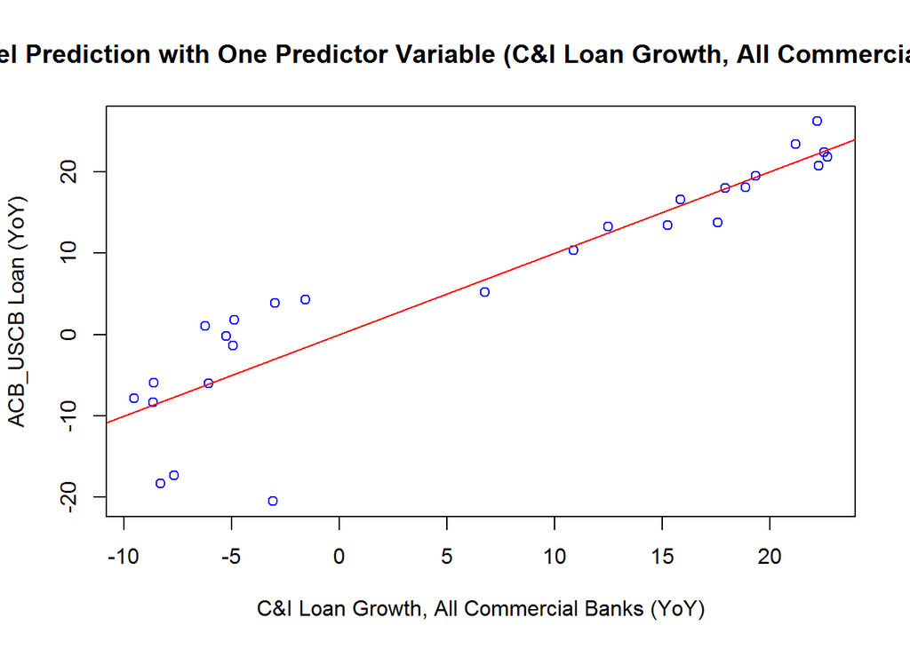

```r
plot(predict(ACB_USCB_Model_6a),ACB_USCB$loans_ACB_USCByoy,
     xlab = "C&I Loan Growth, All Commercial Banks (YoY)", ylab = "ACB_USCB Loan (YoY)", main = "Model Prediction with One Predictor Variable (C&I Loan Growth, All Commercial Banks)", col ="blue")
abline(a=0, b=1, col= "red")
```

**End——————————————————————————————-End**